# MPDW P4

### Menguji Nilai Harapan Sisaan = 0

```r
t.test(resid(model), mu = 0,)
```

```
##
##  One Sample t-test
##
## data:  resid(model)
## t = 6.2112e-17, df = 40, p-value = 1
## alternative hypothesis: true mean is not equal to 0
## 95 percent confidence interval:
##  -3183174  3183174
## sample estimates:
##    mean of x
## 9.782614e-11
```

Berdasarkan t-test didapatkan nilai *p-value* > $\alpha$ (5%), maka tidak tolak H0. Artinya, terdapat cukup bukti untuk menyatakan bahwa nilai harapan sisaan sama dengan 0 pada taraf nyata 5%

### Uji Breusch-Pagan

```r
lmtest::bptest(model)
```

```
##
##  studentized Breusch-Pagan test
##
## data:  model
## BP = 3.473, df = 2, p-value = 0.1761
```

Berdasarkan uji formal Breusch-Pagan didapatkan nilai *p-value* > $\alpha$ (5%), maka tidak tolak H0. Artinya, terdapat cukup bukti untuk menyatakan bahwa ragam sisaan homogen pada taraf nyata 5%.

### Uji Durbin Watson

```r
library(lmtest)
dwtest(model)
```

```
##
##  Durbin-Watson test
##
## data:  model
## DW = 1.1432, p-value = 0.0006568
## alternative hypothesis: true autocorrelation is greater than 0
```

Berdasarkan uji formal Durbin-Watson didapatkan nilai *p-value* < $\alpha$ (5%), maka tolak H0. Artinya terdapat cukup bukti untuk menyatakan adanya autokorelasi pada taraf nyata 5%. Oleh karena itu, diperlukan penanganan lebih lanjut terhadap autokorelasi. Penanganan yang akan dilakukan menggunakan dua metode, yaitu Cochrane-Orcutt dan Hildret-Lu.

### Mengidentifikasi autokorelasi menggunakan ACF dan PACF

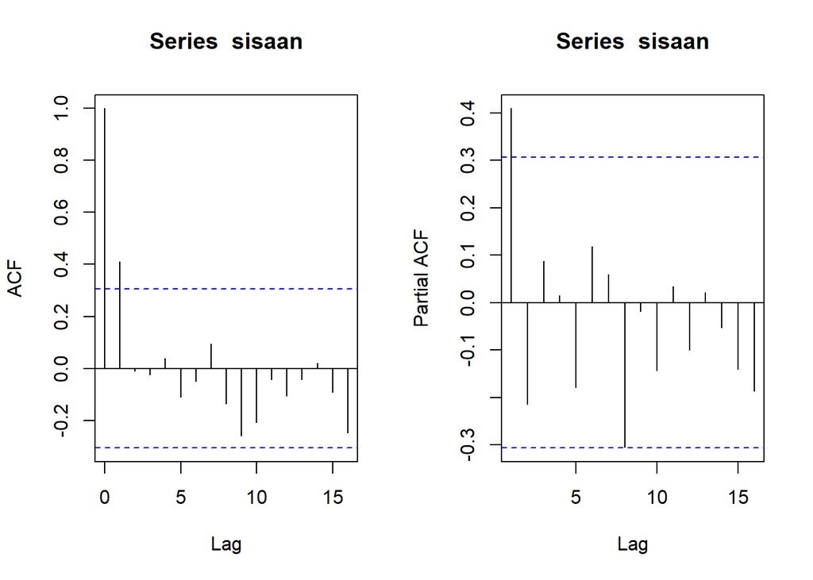

```r
sisaan = model$residuals
par(mfrow = c(1,2))
acf(sisaan)
pacf(sisaan)
```

Berdasarkan plot ACF dan PACF, terlihat bahwa terdapat data yang berada diluar rentang batas autokorelasi.